# Manuscript Report: Low N Sedimentary Site 40_BO

Kaveh Gholamhossein Siah

10 March 2021

### Hydrology

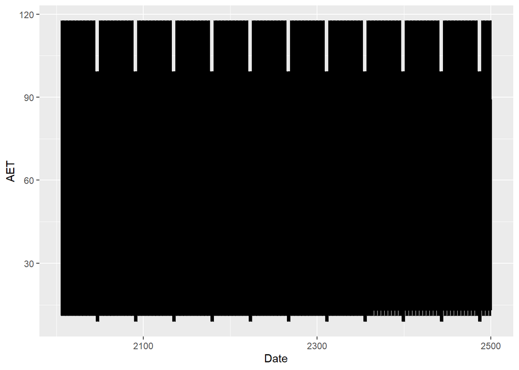

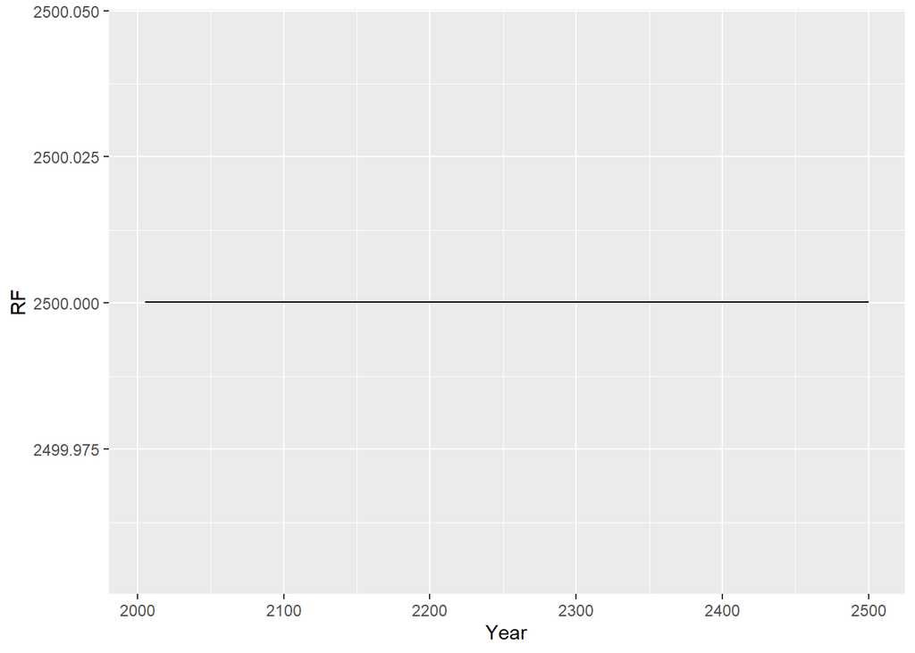

### Soil Solution Results

```r
LL_Year<-Cal_Pretable_LL %>% group_by(YEAR, group_id) %>% summarise(across(Ca:Si, ~sum(.x, na.rm=FALSE)))
```

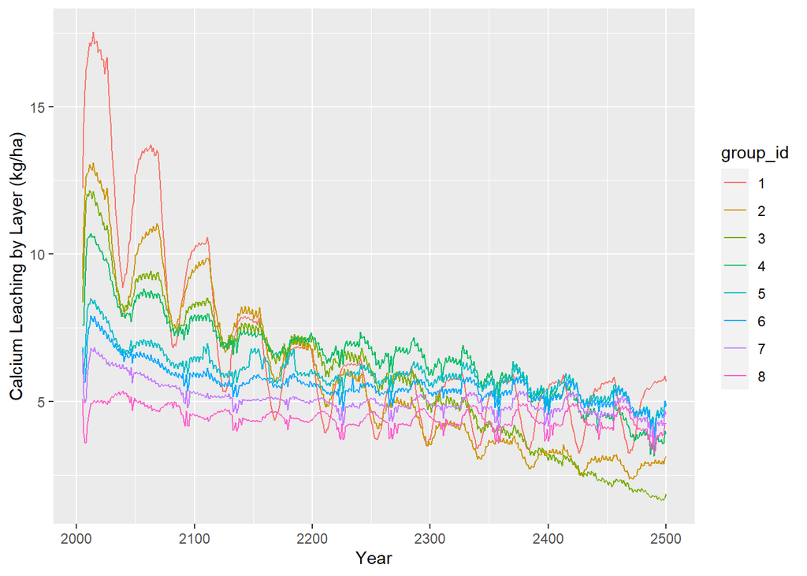

```r
Test_LL<-ggplot(LL_Year, aes(x=YEAR, y=Ca, color=group_id))+geom_line()+labs(x="Year", y="Calcium Leaching by Layer (kg/ha)")
Test_LL
```

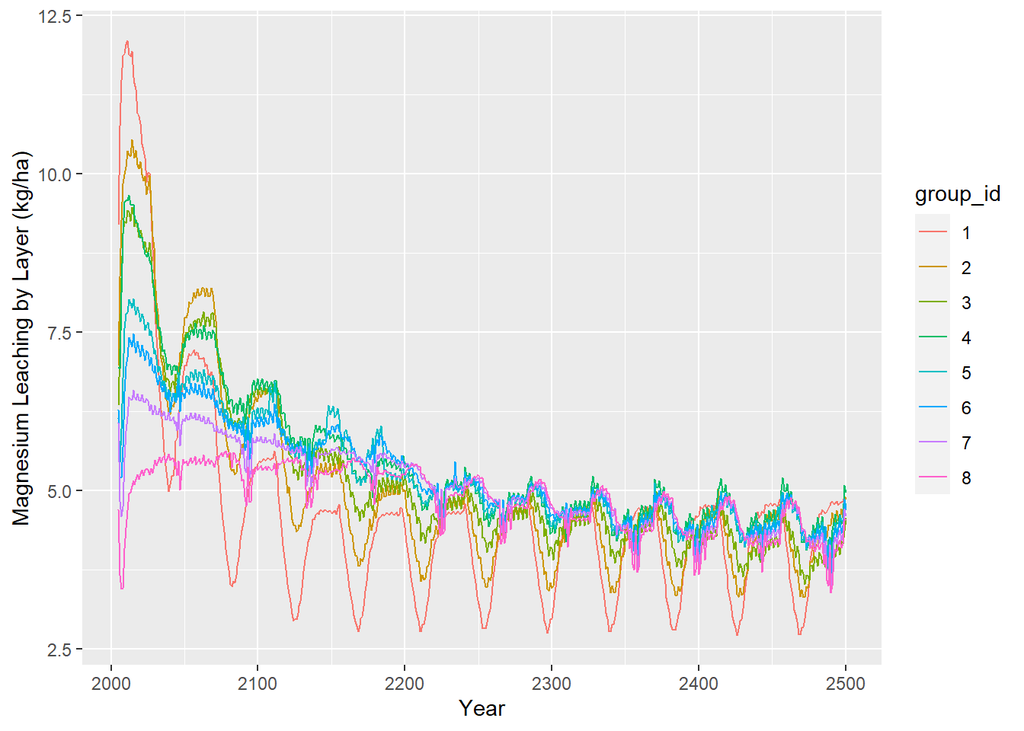

```r
Test_LL<-ggplot(LL_Year, aes(x=YEAR, y=Mg, color=group_id))+geom_line()+labs(x="Year", y="Magnesium Leaching by Layer (kg/ha)")
Test_LL
```

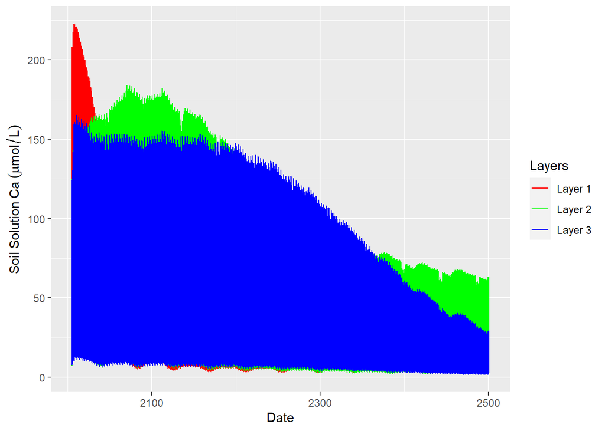

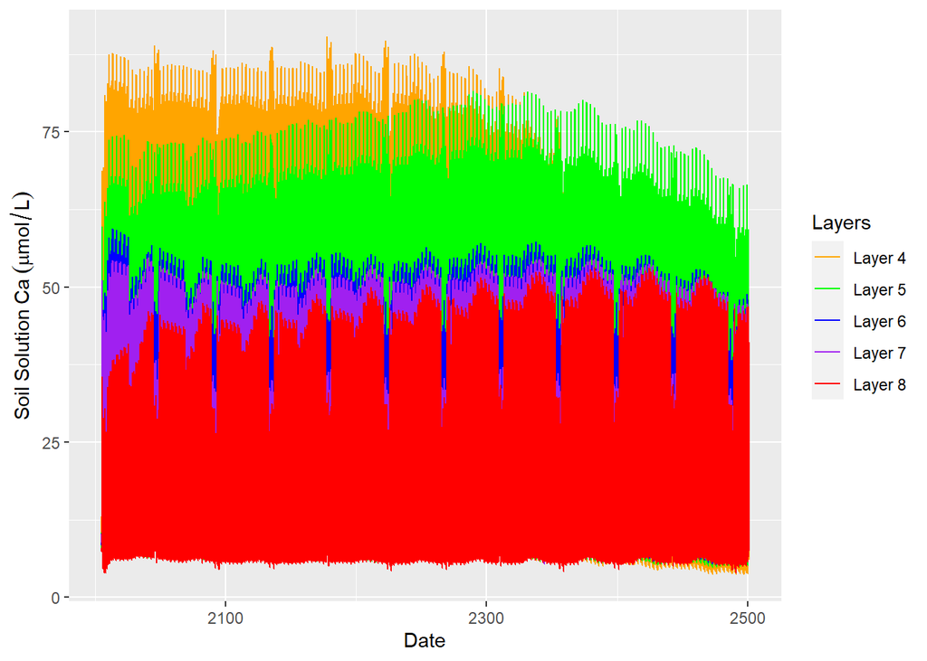

Monthly Calcium Concentrations by Soil Layer

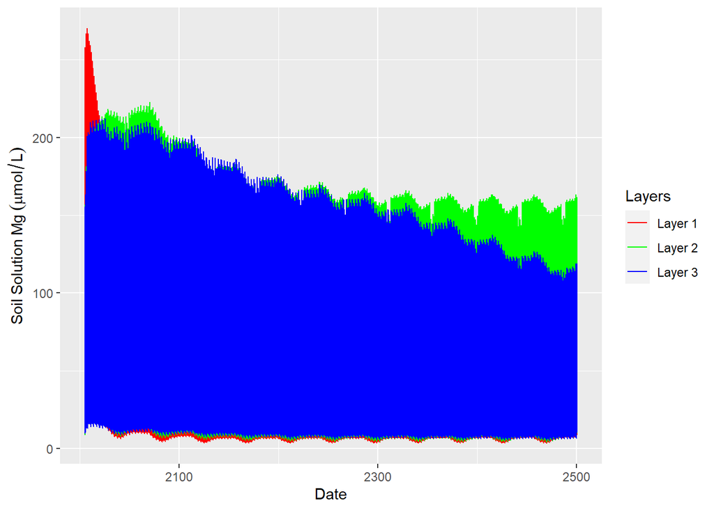

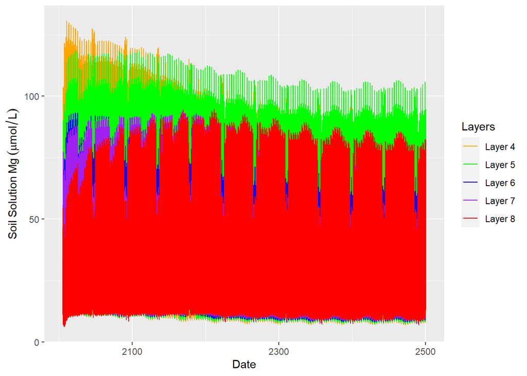

Monthly Magnesium Concentrations by Soil Layer

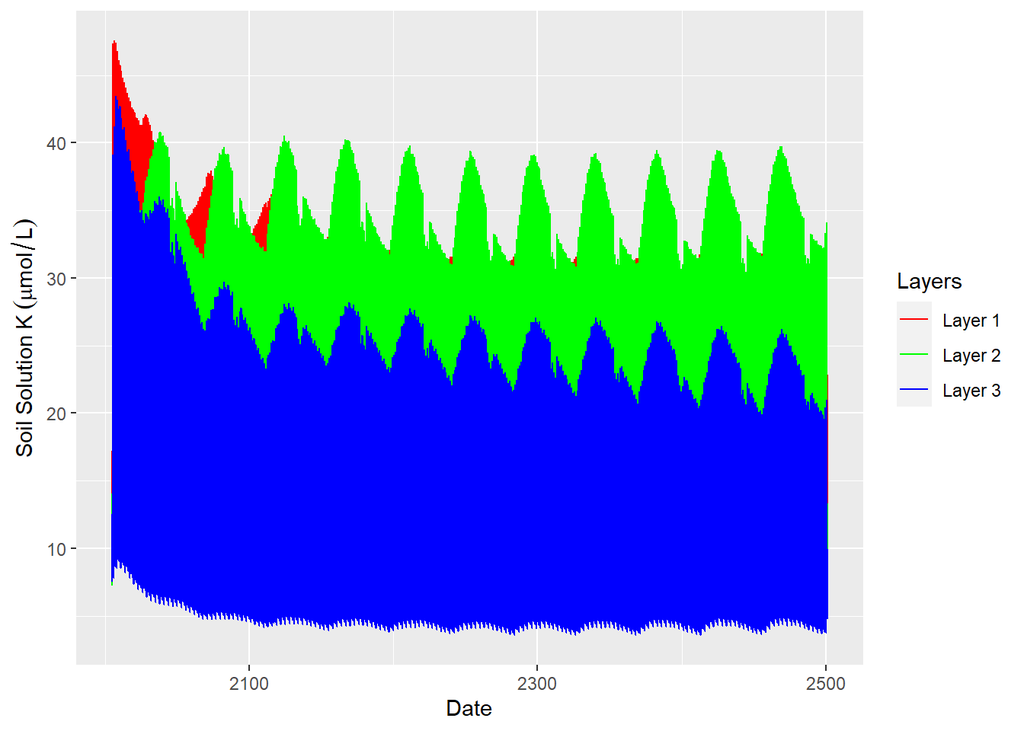

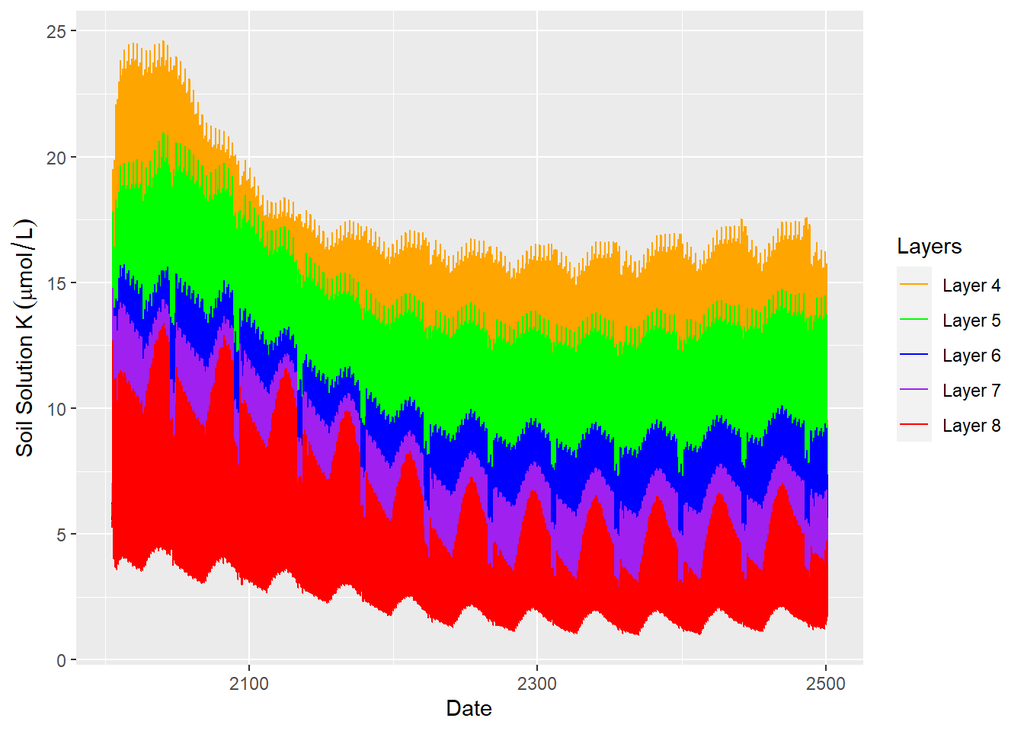

Monthly Potassium Concentrations by Soil Layer

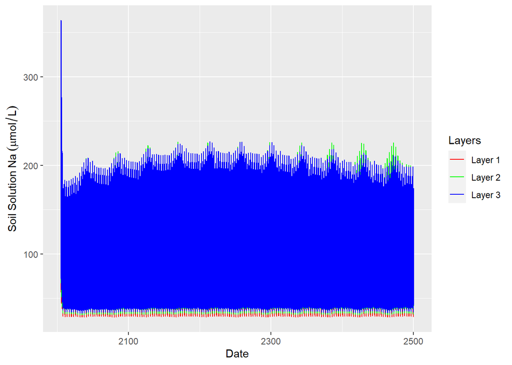

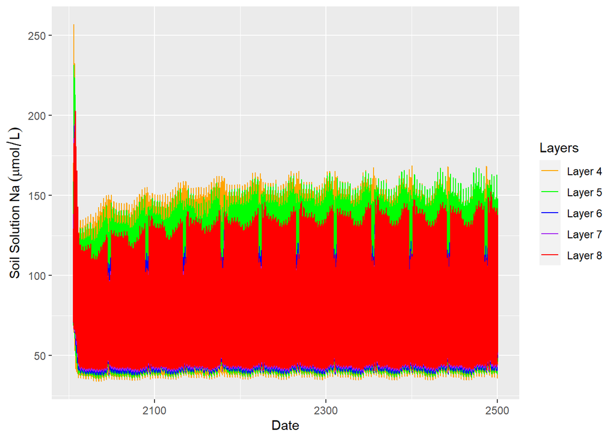

Monthly Sodium Concentrations by Soil Layer

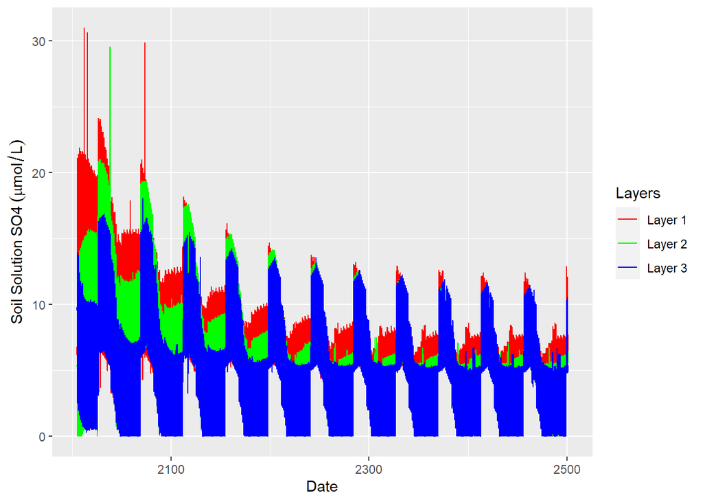

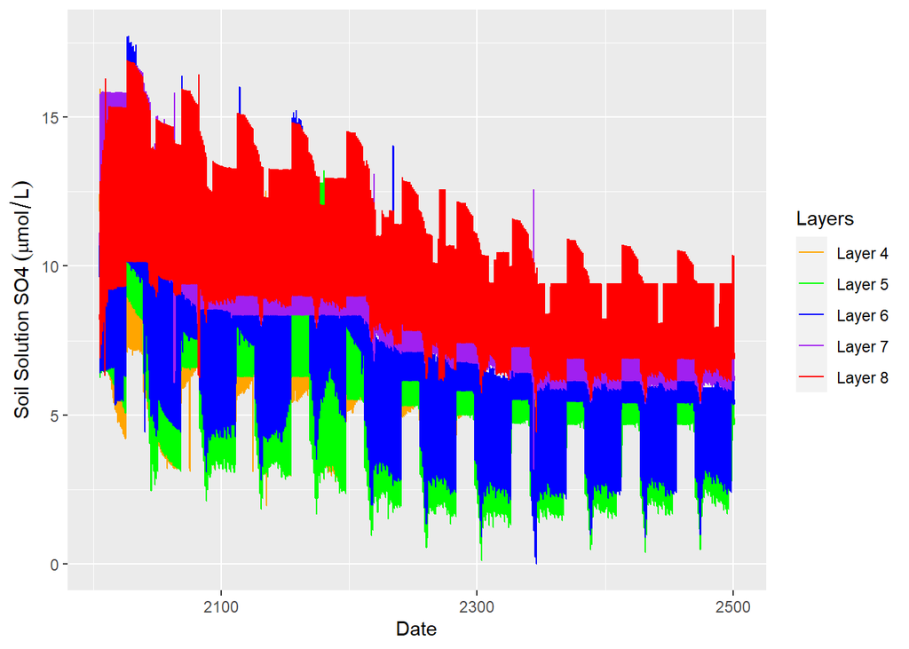

Monthly Sulfate Concentrations by Soil Layer

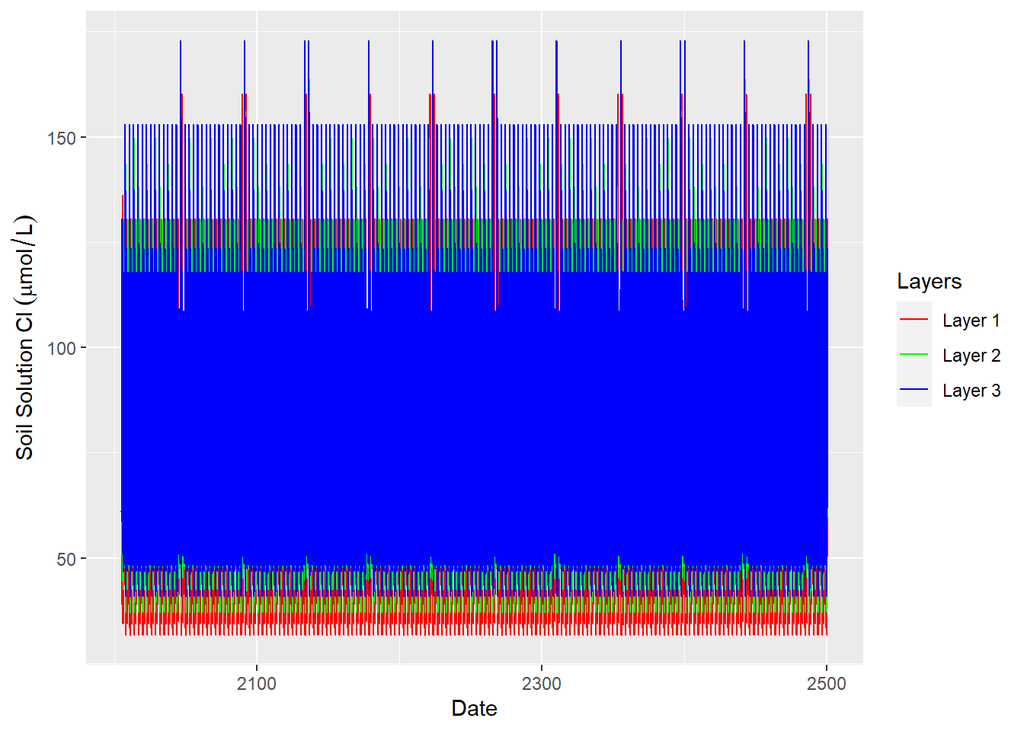

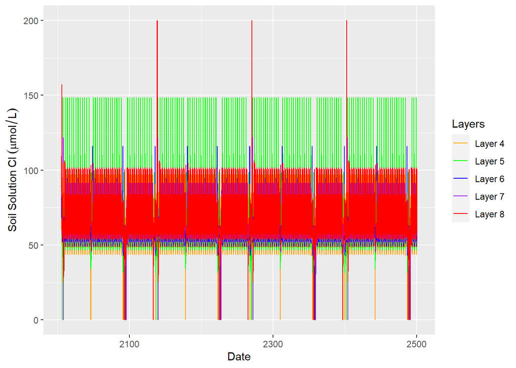

Monthly Chloride Concentrations by Soil Layer

[12 more figures not shown]

```r
Sim_Lysimeter_Flux<-Cal_Pretable_LL %>% filter(group_id %in% c("2", "8")) %>% group_by(group_id, YEAR) %>% summarise(across(Ca:HR, ~sum(.x, na.rm=TRUE))) %>% select(-H, -pH, -R, -HR) %>% filter (YEAR %in% c("2005", "2006")) %>% rename(Depth="group_id")


Sim_Lysimeter_Flux %>% mutate_if(is.numeric, format, digits=2, nsmall= 0) %>%
  kbl(caption = "Simulated Lysimeter Fluxes by Depth (2005-2006)", format="latex", booktabs=TRUE, escape=FALSE, align="c") %>% t(.) %>% kable_styling(latex_options = c("striped", "scale_down", "HOLD_position")) %>%
         kable_styling(font_size = 12) %>% kable_classic(full_width = F, html_font = "Times") %>% add_header_above(c(" "=2,  "kg/ha"=12))
```

[output not shown]

### Lysimeter Comparisons

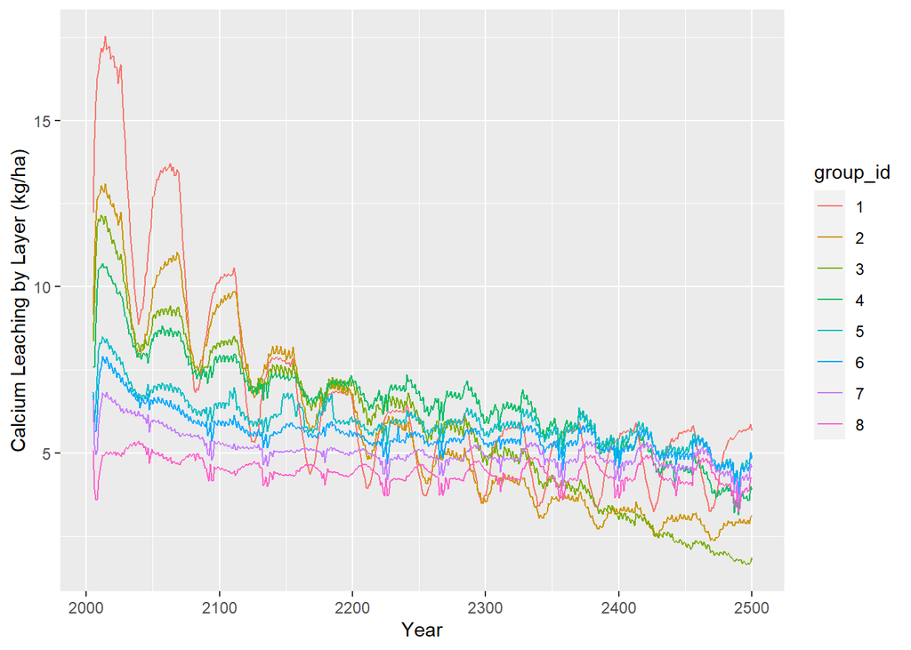

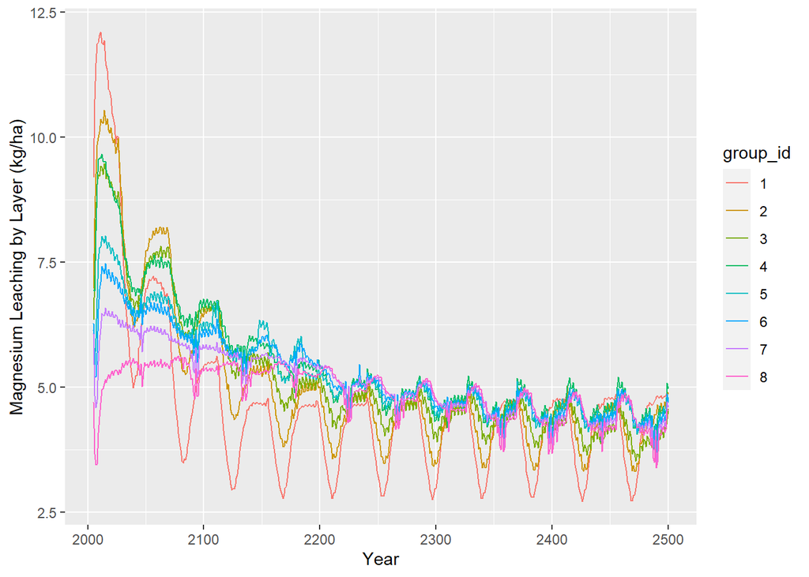

### Weathering Results

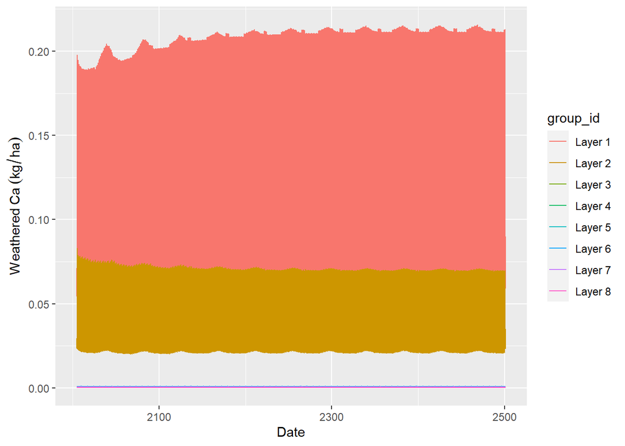

Calcium Weathering (All Layer)

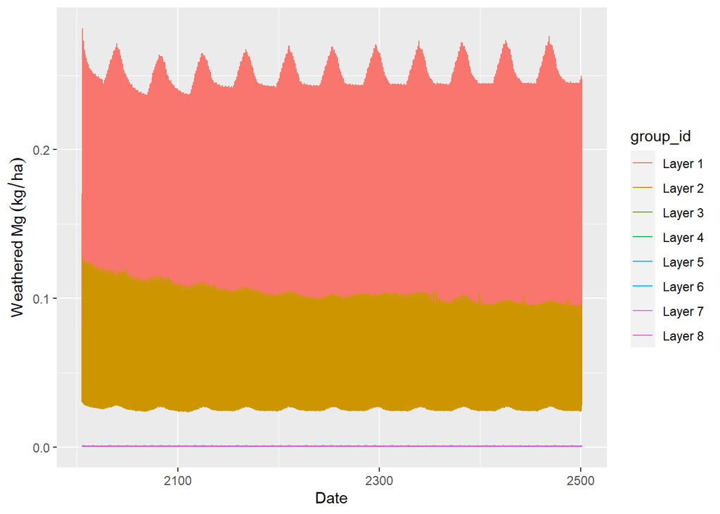

Magnesium Weathering (All Layer)

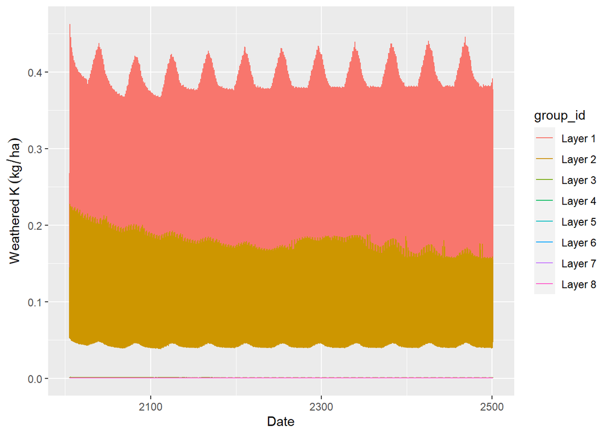

Potassium Weathering (All Layer)

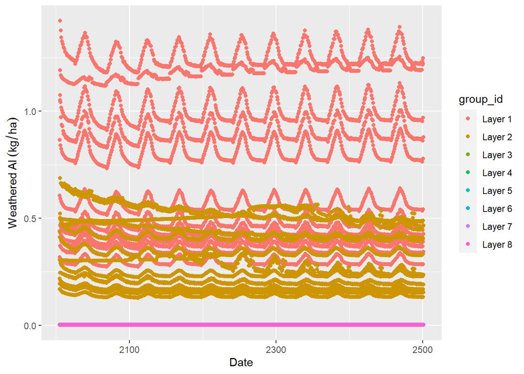

Aluminum Weathering (All Layer)

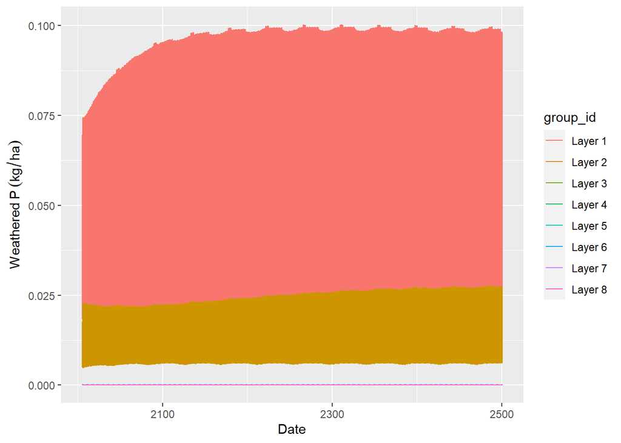

Phosphate Weathering (All Layer)

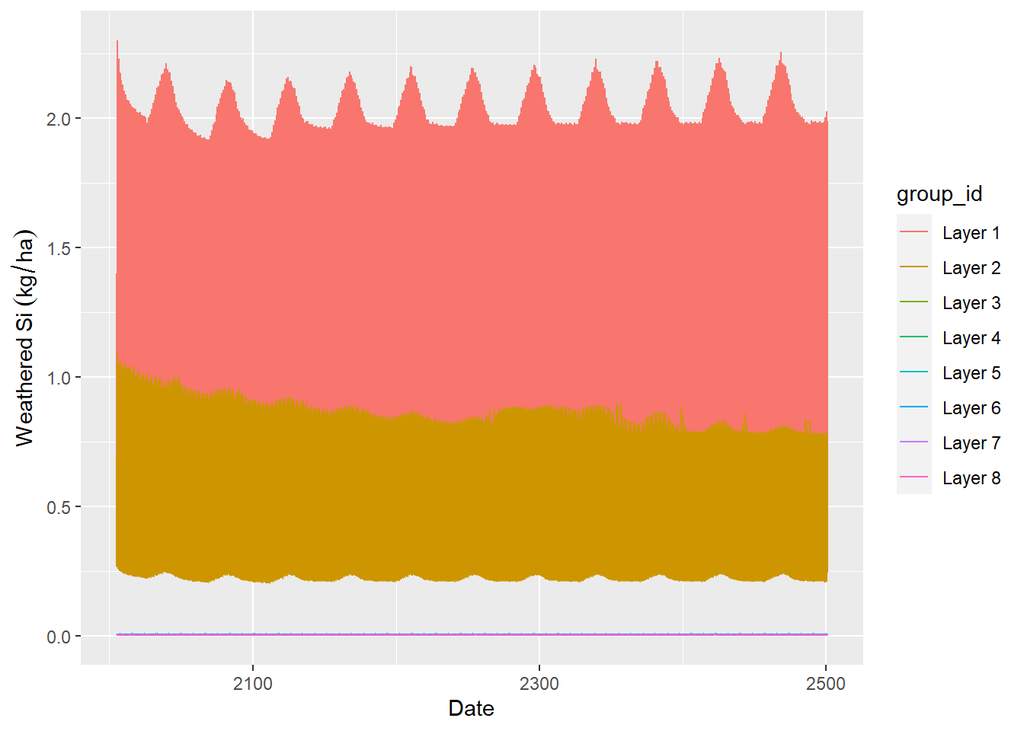

Silica Weathering (All Layer)

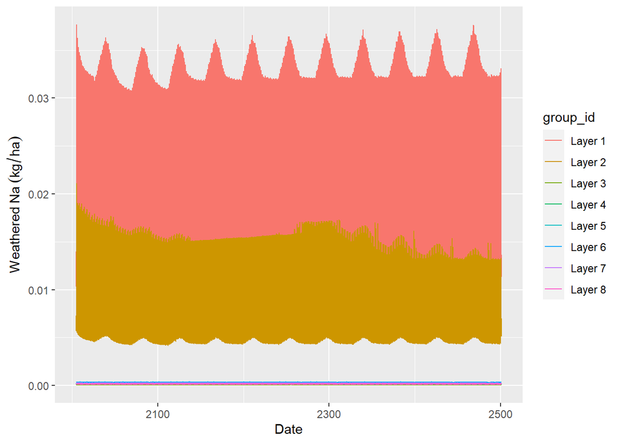

Sodium Weathering (All Layer)

### Litter Pool Results

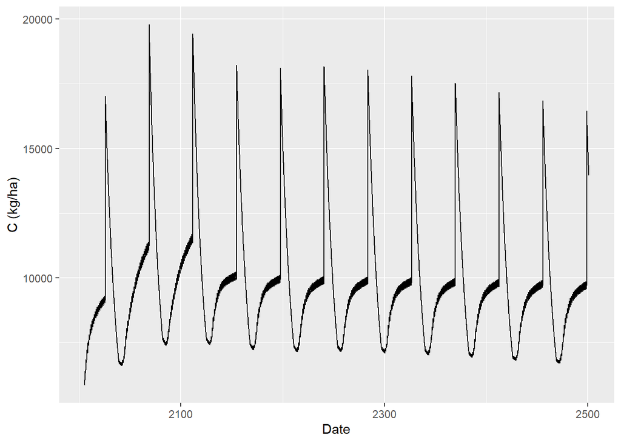

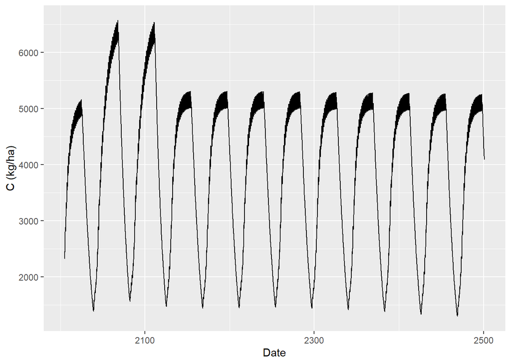

Forest Floor (O-Layer) Carbon Content Over Simulation Period

Looking at a range of soil carbon studies in Douglas-fir forests of the Pacific Northwest, forest floor (defined as non-mineral OM) C content goes from a lower bound of 3,700 kg C/ha in a 9-yr old stand[@cromackSoilCarbonNutrients1999] to 8200 kg C/ha in an average 38 year old stand [edmondsRelationshipsSoilOrganic1994]. These stands were notably N rich compared to the site simulated for the low N site, the soil C should be lower in the simulations as there is about half as much soil N in the low N simulated site as in the sites described in [edmondsRelationshipsSoilOrganic1994]. The high N site has about 21,000 kg N/ha at 1m depth, so it should be modeled to be at the higher end of organic and litter C buildup.

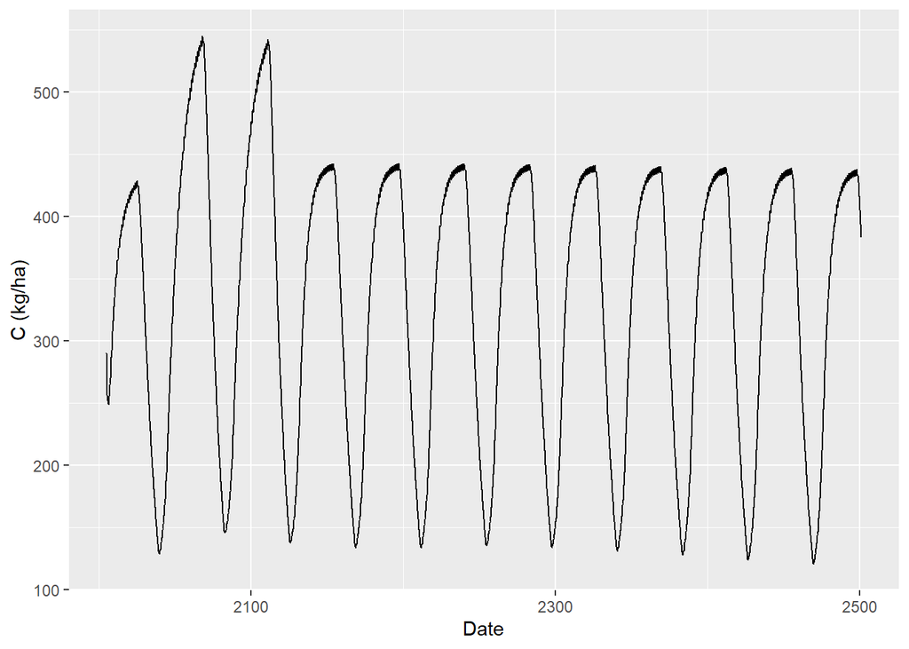

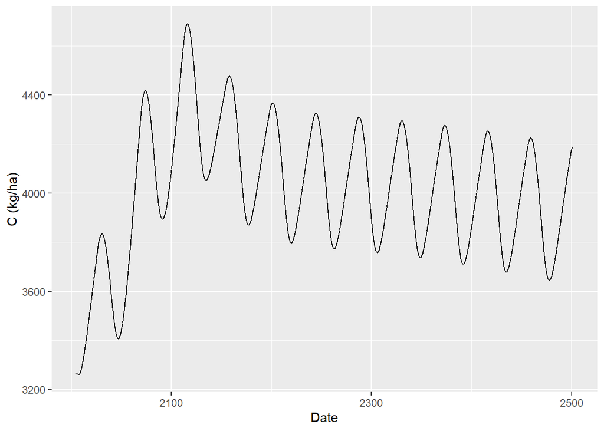

Forest Floor (O-Layer) Carbon Content Over Simulation Period

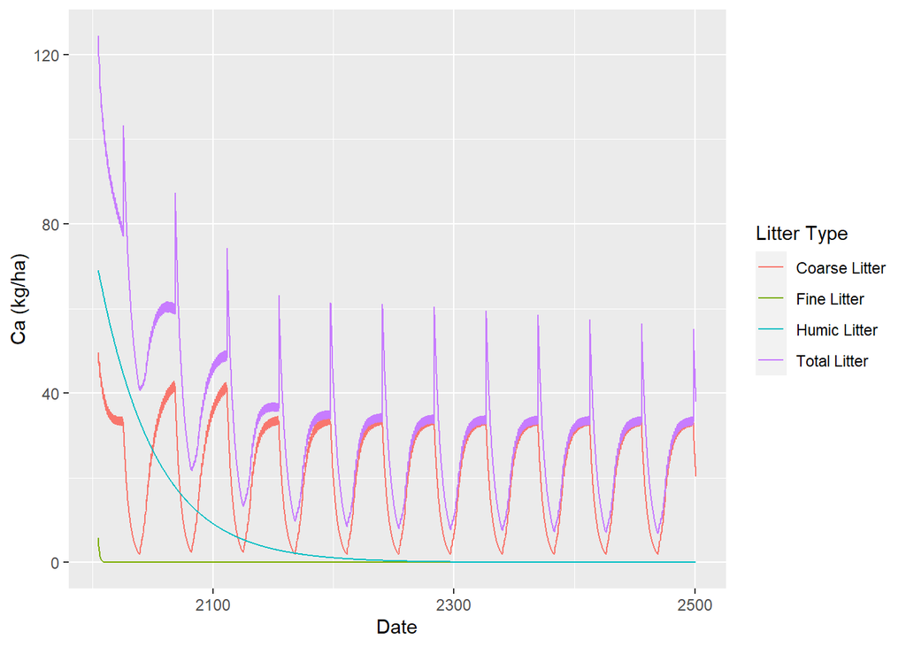

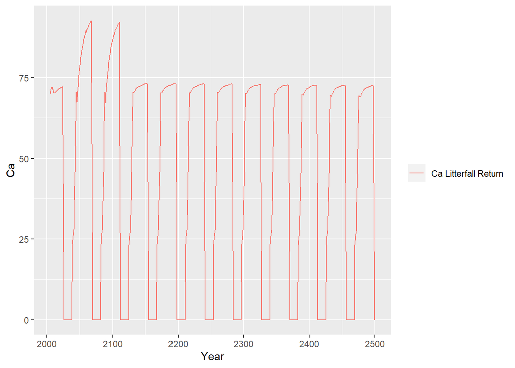

Forest Floor/O-horizon Ca content over time (a). and net annual Ca return in litterfall (b).